# Bibles

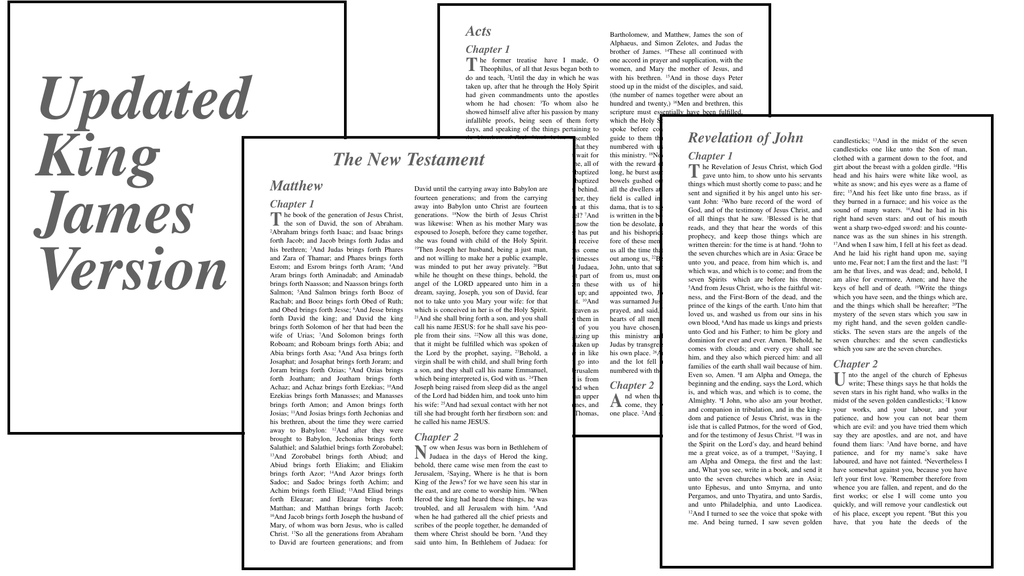

> Jesus said to him, I am the way, the truth, and the life: no man comes to the Father, but by me.

> – John 14:6 (RKJNT)

# A List of All the Bibles

## English

- **A Conservative Version (ACV) ([Read it from the terminal!](https://github.com/rofe33/ACV))**
  - Download The New Testament
  - Download The Old Testament
  - Download The Old Testament & The New Testament
- **American King James Version (AKJV) ([Read it from the terminal!](https://github.com/rofe33/AKJV))**
  - Download The New Testament
  - Download The Old Testament
  - Download The Old Testament & The New Testament
- **Bible in Basic English (BBE) ([Read it from the terminal!](https://github.com/rofe33/BBE))**
  - Download The New Testament
  - Download The Old Testament
  - Download The Old Testament & The New Testament
- **Darby Translation (DARBY) ([Read it from the terminal!](https://github.com/rofe33/DARBY))**
  - Download The New Testament
  - Download The Old Testament
  - Download The Old Testament & The New Testament
- **Douay-Rheims 1899 American Edition (DRA)**
  - Download The New Testament
  - Download The Old Testament
  - Download The Old Testament & The New Testament
- **Geneva Bible 1599**
  - [Download The New Testament](https://github.com/rofe33/Bibles/raw/main/English/Geneva%20Bible%201599/The%20New%20Testament/Geneva1599-the-new-testament.pdf)
  - [Download The Old Testament](https://github.com/rofe33/Bibles/raw/main/English/Geneva%20Bible%201599/The%20Old%20Testament/Geneva1599-the-old-testament.pdf)
  - [Download The Old Testament & The New Testament](https://github.com/rofe33/Bibles/raw/main/English/Geneva%20Bible%201599/The%20Old%20Testament%20%26%20The%20New%20Testament/Geneva1599.pdf)
- **King James Version (KJV)**
  - Download The New Testament
  - Download The Old Testament
  - Download The Old Testament & The New Testament
- **Montgomery New Testament (MNT)**
  - Download The New Testament
- **Revised King James New Testament (RKJNT) ([Read it from the terminal!](https://github.com/rofe33/RKJNT))**
  - Download The New Testament
- **The Living Oracles NT (TLO)**
  - Download The New Testament
- **Twentieth Century New Testament (TCNT)**
  - Download The New Testament
- **Updated King James Version (UKJV)**
  - Download The New Testament
  - Download The Old Testament
  - Download The Old Testament & The New Testament
- **Webster Bible**
  - [Download The New Testament](https://raw.githubusercontent.com/rofe33/Bibles/main/English/Webster%20Bible/The%20New%20Testament/Webster-the-new-testament.pdf)
  - [Download The Old Testament](https://raw.githubusercontent.com/rofe33/Bibles/main/English/Webster%20Bible/The%20Old%20Testament/Webster-the-old-testament.pdf)
  - [Download The Old Testament & The New Testament](https://raw.githubusercontent.com/rofe33/Bibles/main/English/Webster%20Bible/The%20Old%20Testament%20%26%20The%20New%20Testament/Webster.pdf)
- **Weymouth NT 1912 (Weymouth)**
  - Download The New Testament
- **Young’s Literal Translation (YLT)**
  - Download The New Testament
  - Download The Old Testament
  - Download The Old Testament & The New Testament

## Español (Spanish)

- **Reina-Valera Antigua (RVA)**
  - Descarga Nuevo Testamento
  - Descarga Viejo Testamento
  - Descarga Viejo Testamento y Viejo Testamento

## Français (French)

- **La Sainte Bible**
  - Télécharger Le Nouveau Testament
  - Télécharger L’Ancien Testament
  - Télécharger L’Ancien Testament et Le Nouveau Testament
- **Louis Segond (LSG)**
  - Télécharger Le Nouveau Testament
  - Télécharger L’Ancien Testament
  - Télécharger L’Ancien Testament et Le Nouveau Testament

## Italiano (Italian)

- **Conferenza Episcopale Italiana (CEI)**
  - Scarica Nuovo Testamento
  - Scarica Vecchio Testamento
  - Scarica Vecchio Testamento e Nuovo Testamento
- **Giovanni Diodati Bibbia 1649 (ITADIO)**
  - Scarica Nuovo Testamento
  - Scarica Vecchio Testamento
  - Scarica Vecchio Testamento e Nuovo Testamento

# Special Thanks

- To [Peter Schaffter](https://schaffter.ca/about-me.html) (The Creator of [mom](https://schaffter.ca/mom/mom-01.html)), who created the `SKIPTOCENTRY.mom` file and patched several bugs discovered while working on this project.

# Contact Me

Please contact me or open an issue if you have any concerns or suggestions.

- Email: `r3veal@protonmail.ch`

> **Jesus Christ is Lord…**

> **…All The Glory To God.**